# LSE ST510: Foundations of Machine Learning

## Week 7: Decision Trees and Random Forests

### Author: Jin Zhu

- 5.1 Classification Trees
- 5.2 Regression Trees
- 5.3 Bagging and Random Forest

```python
import pandas as pd
import matplotlib.pyplot as plt

import pydot
from IPython.display import Image
import graphviz

from sklearn import tree
from sklearn.model_selection import train_test_split, cross_val_score
from sklearn.model_selection import GridSearchCV
from sklearn.tree import DecisionTreeRegressor, DecisionTreeClassifier, export_graphviz
from sklearn.ensemble import RandomForestRegressor
from sklearn.metrics import mean_squared_error, confusion_matrix, classification_report, accuracy_score

from six import StringIO

import warnings
warnings.simplefilter('ignore')

%matplotlib inline
import seaborn as sns
plt.style.use('seaborn-white')
```

Define a function to create images of tree models using *pydot*.

```python
def print_tree(estimator, features, class_names=None, filled=True):
    tree = estimator
    names = features
    color = filled
    classn = class_names

    dot_data = StringIO()
    export_graphviz(estimator, out_file=dot_data, feature_names=features, class_names=classn, filled=filled)
    graph = pydot.graph_from_dot_data(dot_data.getvalue())
    return(graph)
```

## 5.1 Classification Trees

We use Carseats dataset from *ISLR* `R` package, a dataset containing sales of child car seats at 400 different stores.

```python
carseats = pd.read_csv('Carseats.csv')
carseats.head()
```

|  | Sales | CompPrice | Income | Advertising | Population | Price | ShelveLoc | Age | Education | Urban | US |
| --- | --- | --- | --- | --- | --- | --- | --- | --- | --- | --- | --- |
| 0 | 9.50 | 138 | 73 | 11 | 276 | 120 | Bad | 42 | 17 | Yes | Yes |
| 1 | 11.22 | 111 | 48 | 16 | 260 | 83 | Good | 65 | 10 | Yes | Yes |
| 2 | 10.06 | 113 | 35 | 10 | 269 | 80 | Medium | 59 | 12 | Yes | Yes |
| 3 | 7.40 | 117 | 100 | 4 | 466 | 97 | Medium | 55 | 14 | Yes | Yes |
| 4 | 4.15 | 141 | 64 | 3 | 340 | 128 | Bad | 38 | 13 | Yes | No |

- **Sales**: Unit sales (in thousands) at each location
- **CompPrice**: Price charged by competitor at each location
- **Income**: Community income level (in thousands of dollars)
- **Advertising**: Local advertising budget for company at each location (in thousands of dollars)
- **Population**: Population size in region (in thousands)
- **Price**: Price company charges for car seats at each site
- **ShelveLoc**: A factor with levels Bad, Good and Medium indicating the quality of the shelving location for the car seats at each site
- **Age**: Average age of the local population
- **Education**: Education level at each location
- **Urban**: A factor with levels No and Yes to indicate whether the store is in an urban or rural location
- **US**: A factor with levels No and Yes to indicate whether the store is in the US or not

We create the response variable *High*, which is "True" if the *Sales* variable exceeds 8 and "False" otherwise.

```python
carseats['High'] = carseats.Sales >= 8
carseats['Urban'] = carseats.Urban == 'Yes'
carseats['US'] = carseats.US == 'Yes'
carseats.ShelveLoc = carseats.ShelveLoc.map({'Bad':0, 'Medium':1, 'Good':2})
carseats.head()
```

|  | Sales | CompPrice | Income | Advertising | Population | Price | ShelveLoc | Age | Education | Urban | US | High |
| --- | --- | --- | --- | --- | --- | --- | --- | --- | --- | --- | --- | --- |
| 0 | 9.50 | 138 | 73 | 11 | 276 | 120 | 0 | 42 | 17 | True | True | True |
| 1 | 11.22 | 111 | 48 | 16 | 260 | 83 | 2 | 65 | 10 | True | True | True |
| 2 | 10.06 | 113 | 35 | 10 | 269 | 80 | 1 | 59 | 12 | True | True | True |
| 3 | 7.40 | 117 | 100 | 4 | 466 | 97 | 1 | 55 | 14 | True | True | False |
| 4 | 4.15 | 141 | 64 | 3 | 340 | 128 | 0 | 38 | 13 | True | False | False |

Fit a classification tree to predict *High* by using all variables except *Sales*.

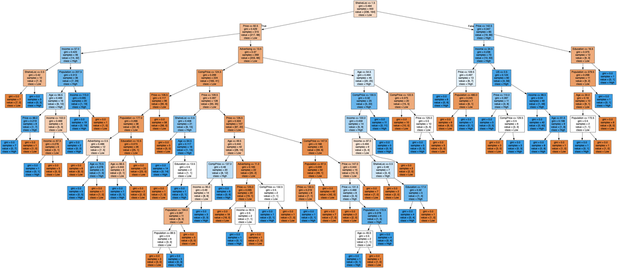

```python
model = DecisionTreeClassifier()
model.fit(X=carseats.drop(['Sales', 'High'], axis=1) , y=carseats.High)
graph, = print_tree(model, features=carseats.columns[1:-1],class_names=['Low', 'High'])
Image(graph.create_png())
```

Now we run classification tree on the training dataset.

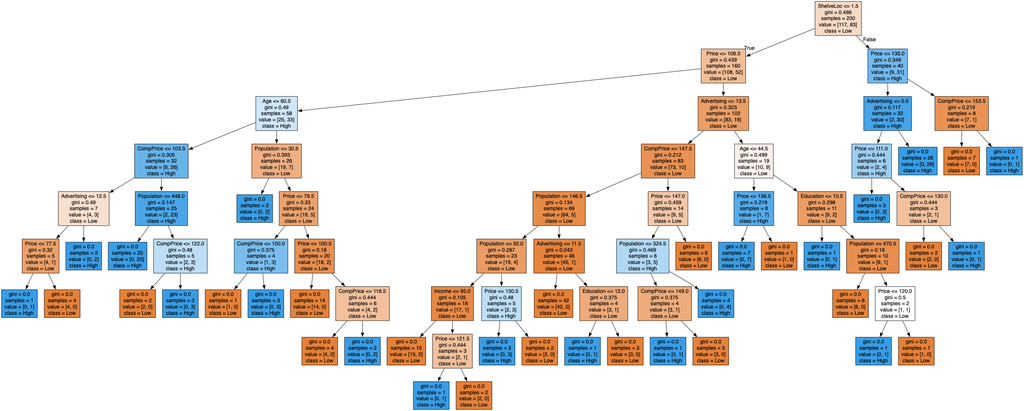

```python
carseats_train, carseats_test = train_test_split(carseats, train_size=0.5, random_state=1)
model = DecisionTreeClassifier()
model.fit(X=carseats_train.drop(['Sales', 'High'], axis=1) , y=carseats_train.High)
graph, = print_tree(model, features=carseats.columns[1:-1],class_names=['Low', 'High'])
Image(graph.create_png())
```

Predict the class on the test dataset and construct the confusion matrix.

```python
predict = model.predict(X=carseats_test.drop(['Sales', 'High'], axis=1))

cm = pd.DataFrame(confusion_matrix(carseats_test.High,predict), index=['Low','High'], columns=['Low','High'])
cm.index.name = 'Predicted'
cm.columns.name = 'True'
cm
```

| True Predicted | Low | High |
| --- | --- | --- |
| Low | 81 | 38 |
| High | 27 | 54 |

```python
print(classification_report(carseats_test.High, predict, target_names=['Low','High']))
```

```
              precision    recall  f1-score   support

         Low       0.75      0.68      0.71       119
        High       0.59      0.67      0.62        81

    accuracy                           0.68       200
   macro avg       0.67      0.67      0.67       200
weighted avg       0.68      0.68      0.68       200
```

Misclassification error:

```python
sum(predict != carseats_test.High) / len(predict)
```

```
0.325
```

### Tree Pruning

We consider whether pruning the tree might lead to improved results.

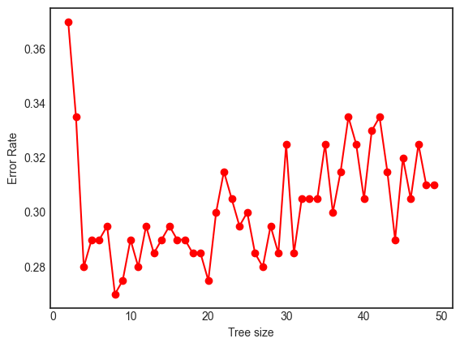

```python
parameters = {'max_leaf_nodes':range(2, 50)}

model = DecisionTreeClassifier()
cv_tree = GridSearchCV(model, parameters, cv=10, scoring='accuracy')
cv_tree.fit(X=carseats_train[carseats_train.columns[1:-1]] , y=carseats_train.High)

cv_tree.cv_results_.keys()

fig, ax = plt.subplots()
ax.plot( range(2,50),1-cv_tree.cv_results_['mean_test_score'], 'ro-')
ax.set_ylabel('Error Rate')
ax.set_xlabel('Tree size')
```

```python
best_model = cv_tree.best_estimator_
cv_tree.best_params_
```

```
{'max_leaf_nodes': 8}
```

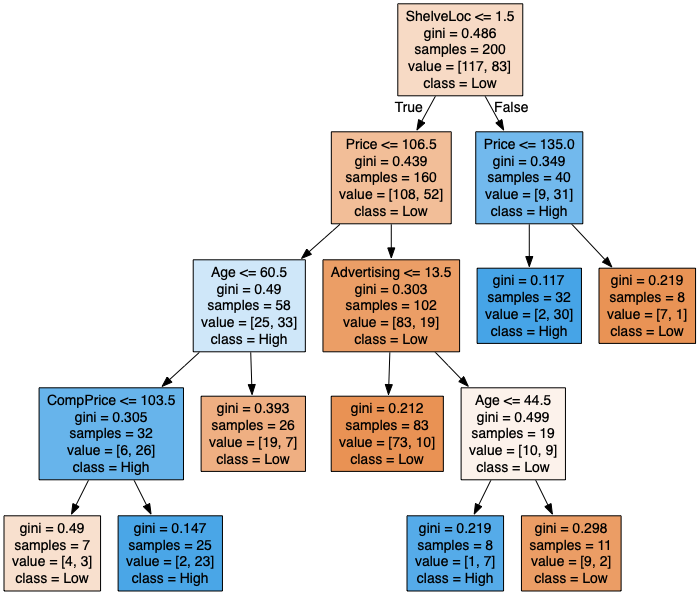

```python
graph, = print_tree(best_model, features=carseats.columns[1:-1],class_names=['Low', 'High'])
Image(graph.create_png())
```

Compute the misclassification error using the pruned tree.

```python
best_predict = best_model.predict(X=carseats_test[carseats_test.columns[1:-1]])
sum(best_predict != carseats_test.High) / len(best_predict)
```

```
0.275
```

## 5.2 Regression Trees

We use Boston Housing dataset. *MEDV* is the response variable.

```python
boston = pd.read_csv('Boston.csv')
boston.head()
```

|  | CRIM | ZN | INDUS | CHAS | NOX | RM | AGE | DIS | RAD | TAX | PTRATIO | BLACK | LSTAT | MEDV |
| --- | --- | --- | --- | --- | --- | --- | --- | --- | --- | --- | --- | --- | --- | --- |
| 0 | 0.00632 | 18.0 | 2.31 | 0 | 0.538 | 6.575 | 65.2 | 4.0900 | 1 | 296 | 15.3 | 396.90 | 4.98 | 24.0 |
| 1 | 0.02731 | 0.0 | 7.07 | 0 | 0.469 | 6.421 | 78.9 | 4.9671 | 2 | 242 | 17.8 | 396.90 | 9.14 | 21.6 |
| 2 | 0.02729 | 0.0 | 7.07 | 0 | 0.469 | 7.185 | 61.1 | 4.9671 | 2 | 242 | 17.8 | 392.83 | 4.03 | 34.7 |
| 3 | 0.03237 | 0.0 | 2.18 | 0 | 0.458 | 6.998 | 45.8 | 6.0622 | 3 | 222 | 18.7 | 394.63 | 2.94 | 33.4 |
| 4 | 0.06905 | 0.0 | 2.18 | 0 | 0.458 | 7.147 | 54.2 | 6.0622 | 3 | 222 | 18.7 | 396.90 | 5.33 | 36.2 |

**CRIM**: per capita crime rate by town.

**ZN**: proportion of residential land zoned for lots over 25,000 sq.ft.

**INDUS**: proportion of non-retail business acres per town.

**CHAS**: Charles River dummy variable (= 1 if tract bounds river; 0 otherwise).

**NOX**: nitrogen oxides concentration (parts per 10 million).

**RM**: average number of rooms per dwelling.

**AGE**: proportion of owner-occupied units built prior to 1940.

**DIS**: weighted mean of distances to five Boston employment centres.

**RAD**: index of accessibility to radial highways

...

**MEDV**: median value of owner-occupied homes in $1000s.

Split the data into training and test datasets.

```python
boston_train, boston_test = train_test_split(boston, train_size=0.5, random_state=1)
```

We use MSE (default) to find splits and set the maximum depth of tree = 3.

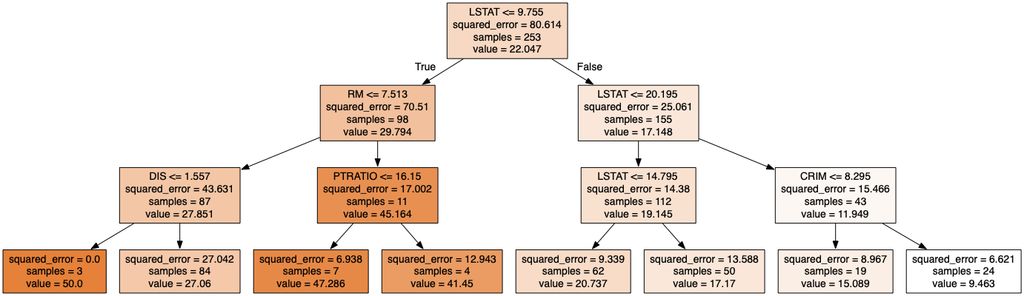

```python
model = DecisionTreeRegressor(max_depth=3)
model.fit(X=boston_train.drop(['MEDV'], axis=1), y=boston_train.MEDV)
graph, = print_tree(model, features=boston.columns.drop(['MEDV']))
Image(graph.create_png())
```

Compare the predicted and true values.

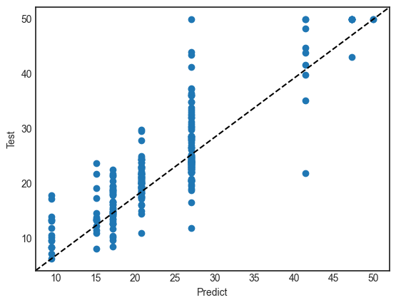

```python
predict = model.predict(X=boston_test.drop(['MEDV'], axis=1))
fig, ax = plt.subplots()
ax.scatter(predict, boston_test.MEDV, label='MEDV')
ax.plot([0, 1], [0, 1], '--k', transform=plt.gca().transAxes)
ax.set_xlabel('Predict')
ax.set_ylabel('Test')
```

Compute the test MSE.

```python
mean_squared_error(boston_test.MEDV,predict)
```

```
24.07874500815818
```

We use 10-fold cross validation to find the best number of leaf nodes. Note that all scorer objects follow the convention that **higher return values are bettter than lower return values** so we use the negated value of MSE.

```python
parameters = {'max_leaf_nodes': range(2, 15)}
model = DecisionTreeRegressor()
cv_tree = GridSearchCV(model, parameters, cv=10, scoring='neg_mean_squared_error')
cv_tree.fit(X=boston.drop(['MEDV'], axis=1), y=boston.MEDV)
```

```
GridSearchCV(cv=10, estimator=DecisionTreeRegressor(),
             param_grid={'max_leaf_nodes': range(2, 15)},
             scoring='neg_mean_squared_error')
```

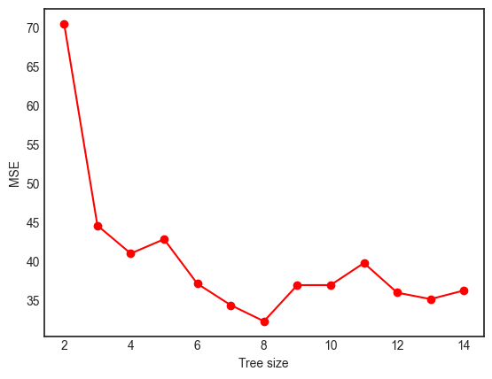

```python
fig, ax = plt.subplots()
ax.plot( range(2,15),-cv_tree.cv_results_['mean_test_score'], 'ro-')
ax.set_xlabel('Tree size')
ax.set_ylabel('MSE')
```

```python
cv_tree.best_params_
```

```
{'max_leaf_nodes': 8}
```

We fit the tree by using the CV result.

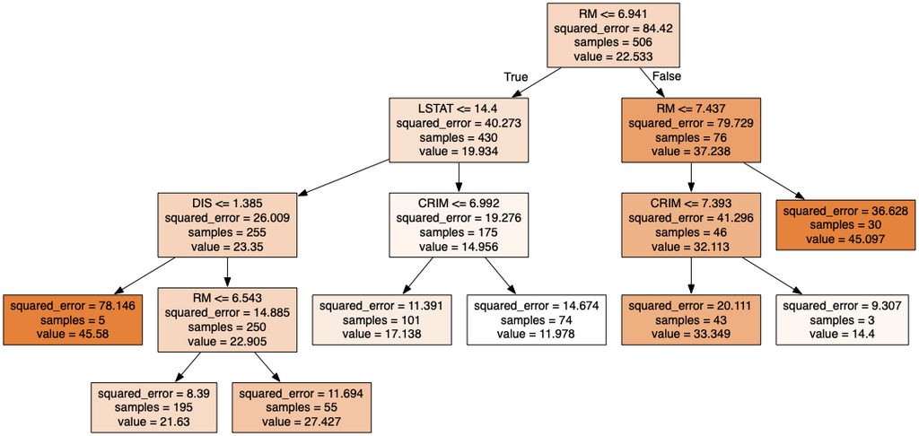

```python
best_model = cv_tree.best_estimator_
graph, = print_tree(best_model, features=boston.columns.drop(['MEDV']))
Image(graph.create_png())
```

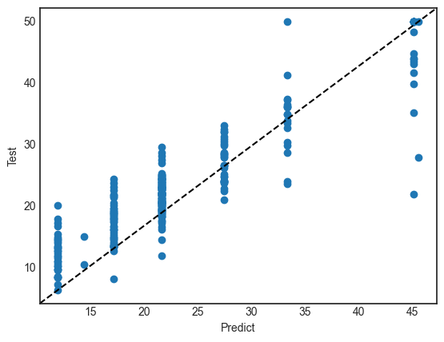

```python
best_predict = best_model.predict(X=boston_test.drop(['MEDV'], axis=1))
fig, ax = plt.subplots()
ax.scatter(best_predict, boston_test.MEDV, label='MEDV')
ax.plot([0, 1], [0, 1], '--k', transform=plt.gca().transAxes)
ax.set_xlabel('Predict')
ax.set_ylabel('Test')
```

```python
mean_squared_error(boston_test.MEDV,best_predict)
```

```
15.466926404185816
```

## 5.3 Bagging and Random Forest

```python
X = boston_train.drop(['MEDV'], axis=1)
y = boston_train.MEDV
X.shape
```

```
(253, 13)
```

### Bagging

There are 13 features in the dataset. Recall that bagging is simply a special case of a random forest with $m = p$, here we use all features.

```python
bagging = RandomForestRegressor(max_features=13, random_state=1)
bagging.fit(X=X, y=y)
```

```
RandomForestRegressor(max_features=13, random_state=1)
```

Predicted values on the testing data using bagging.

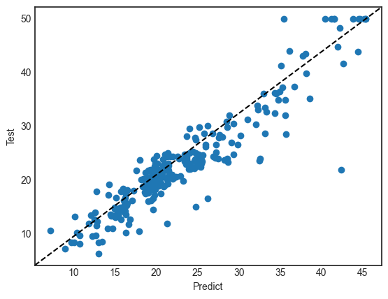

```python
predict = bagging.predict(X=boston_test.drop(['MEDV'], axis=1))
fig, ax = plt.subplots()
ax.scatter(predict, boston_test.MEDV, label='MEDV')
ax.plot([0, 1], [0, 1], '--k', transform=plt.gca().transAxes)
ax.set_xlabel('Predict')
ax.set_ylabel('Test')
```

The test MSE:

```python
mean_squared_error(boston_test.MEDV,predict)
```

```
12.02672559683794
```

### Random Forest

Growing a random forest is exactly the same way. By default, *max_features* = $p$. Here we use *max_features* $ = \sqrt{p}$.

```python
randomForest = RandomForestRegressor(max_features="sqrt", random_state=11)
randomForest.fit(X=X, y=y)
```

```
RandomForestRegressor(max_features='sqrt', random_state=11)
```

```
The test MSE is 13.01357290513834.
```

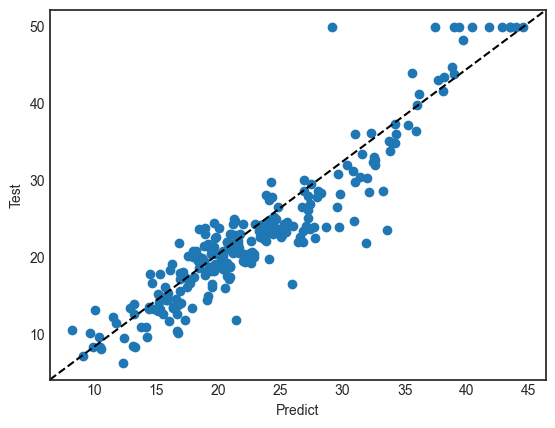

```python
predict = randomForest.predict(X=boston_test.drop(['MEDV'], axis=1))
fig, ax = plt.subplots()
ax.scatter(predict, boston_test.MEDV, label='MEDV')
ax.plot([0, 1], [0, 1], '--k', transform=plt.gca().transAxes)
ax.set_xlabel('Predict')
ax.set_ylabel('Test')
print(f"The test MSE is {mean_squared_error(boston_test.MEDV, predict)}.")
```

Now we try *max_features* $ = 6$.

```python
randomForest = RandomForestRegressor(max_features=6, random_state=1)
randomForest.fit(X=X, y=y)
```

```
RandomForestRegressor(max_features=6, random_state=1)
```

```
The test MSE is 11.246821798418969.
```

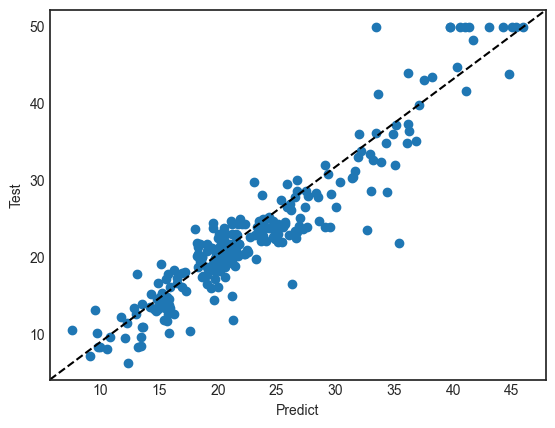

```python
predict = randomForest.predict(X=boston_test.drop(['MEDV'], axis=1))
fig, ax = plt.subplots()
ax.scatter(predict, boston_test.MEDV, label='MEDV')
ax.plot([0, 1], [0, 1], '--k', transform=plt.gca().transAxes)
ax.set_xlabel('Predict')
ax.set_ylabel('Test')
print(f"The test MSE is {mean_squared_error(boston_test.MEDV,predict)}.")
```

We can view the importance of each variable.

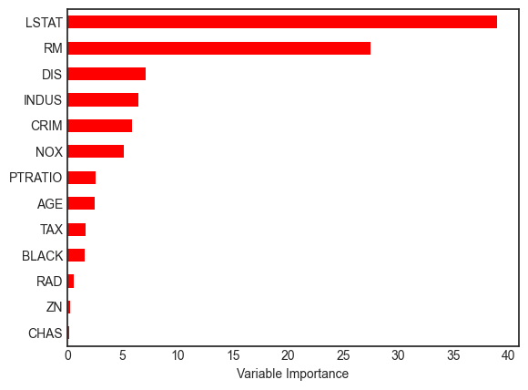

```python
Importance = pd.DataFrame({'Importance':randomForest.feature_importances_*100}, index=X.columns)
Importance.sort_values('Importance', axis=0, ascending=True).plot(kind='barh', color='r', )
plt.xlabel('Variable Importance')
plt.gca().legend_ = None
```

**RM**: average number of rooms per dwelling.

**CHAS**: Charles River dummy variable (= 1 if tract bounds river; 0 otherwise).